# Multiple Linear Regression

**Multiple Linear Regression**: An extension of simple linear regression into where we can estimate a response variable $Y$ based on multiple explanatory variables $X_1,X_2,\dots,X_{k-1}$. $k-1$ is the number of explanatory variables in our linear structure.

## Assumptions Needed for Multiple Linear Regression Models

(Note, these assumptions are the same for simple linear regression, just extended to multiple linear regression)

- Existence
- Independence
- Linearity: $\mu_{Y|\boldsymbol{X}} = \beta_0 + \beta_1X_{i,1} + \beta_2X_{i,2} + \dots + \beta_{k-1}X_{i,k-1}$
- Homoscedasticity: $\sigma_{Y|\boldsymbol{X}}^2 = \sigma^2$
- Normality

## “Least squares” regression estimate

Define the following:
$$\boldsymbol{y}_{n \times 1} = \begin{bmatrix} y_1 \\ y_2 \\ \vdots \\ y_n \end{bmatrix}$$

$$\boldsymbol{X}_{n \times k} = \begin{bmatrix} 1 & x_{1,1} & x_{1,2} & \cdots & x_{1,k-1} \\ 1 & x_{2,1} & x_{2,2} & \cdots & x_{2,k-1} \\ \vdots & \vdots & \vdots & \ddots & \vdots \\ 1 & x_{n,1} & x_{n,2} & \cdots & x_{n,k-1} \end{bmatrix}$$

$$\boldsymbol{\beta}_{k \times 1} = \begin{bmatrix} \beta_0 \\ \beta_1 \\ \vdots \\ \beta_{k-1} \end{bmatrix}$$

$$\boldsymbol{\epsilon}_{n \times 1} = \begin{bmatrix} \epsilon_1 \\ \epsilon_2 \\ \vdots \\ \epsilon_n \end{bmatrix}$$

$\boldsymbol{y}$ is the vector of responses, $\boldsymbol{X}$ is our design matrix/regression matrix, $\boldsymbol{\beta}$ is the parameter vector, and $\boldsymbol{\epsilon}$ is the vector of the errors/residuals.

Combining these definitions and assumptions, we have:

$$\boldsymbol{y} = \boldsymbol{X}\boldsymbol{\beta} + \boldsymbol{\epsilon},$$
$$\boldsymbol{\epsilon} \sim \mathcal{N}(\boldsymbol{0},\sigma^2 \boldsymbol{I}_{n\times n}),$$

where $\boldsymbol{I}_{n \times n}$ is an $n \times n$ identity matrix (the notation for when we assume observations are independent), and the estimates of $\boldsymbol{\beta}$ are the values that minimize the sum of squared errors:

$$\hat{\boldsymbol{\beta}} = \min_\boldsymbol{\beta} \sum_{i = 1}^n (y_i - \boldsymbol{X}_i \boldsymbol{\beta})^2 = \min_{\boldsymbol{\beta}} (\boldsymbol{y} - \boldsymbol{X}\boldsymbol{\beta})'(\boldsymbol{y} - \boldsymbol{X}\boldsymbol{\beta}),$$
where $\boldsymbol{X}_i$ is the $i^{th}$ row of the matrix $\boldsymbol{X}$.

- Recall, to minimize a function we want to take its derivative and set it equal to 0. However, we need to take the derivative of the sum of squared errors with respect to all of the model parameters. In statistics, this calculation of multiple derivatives is called the **gradient**. So, $\hat{\boldsymbol{\beta}}$ is the value of $\boldsymbol{\beta}$ where

$$2\boldsymbol{X}'(\boldsymbol{y} - \boldsymbol{X}\boldsymbol{\beta}) = \boldsymbol{0}$$

Performing some arithmetic and calculus, we can say that

$$\hat{\boldsymbol{\beta}} = (\boldsymbol{X}'\boldsymbol{X})^{-1}\boldsymbol{X}'\boldsymbol{y}$$

### Example

e.g. $\beta$ is a single parameter, Beta hat is the value that minimizes Sum((yi - xiBeta)^2).

$S = \sum 2(y_i - x_i \beta)$

In the data folder, there is a dataset on health expenditures not covered by insurance along with several factors about the policyholders. Find a least squares regression model for predicting health care expenditures by all of the other variables in the dataset.

```r
health <- read.csv("Data/insurance.csv")
#mod <- lm(charges ~ age + sex + bmi + children + smoker + region, health)
# this is the long way above
mod <- lm(charges ~ . , health) #period means include every other variable in the dataset
summary(mod)$coefficients
```

```
                   Estimate Std. Error     t value     Pr(>|t|)
(Intercept)     -11938.5386  987.81918 -12.0857530 5.579044e-32
age                256.8564   11.89885  21.5866552 7.783217e-89
sexmale           -131.3144  332.94544  -0.3944020 6.933475e-01
bmi                339.1935   28.59947  11.8601306 6.498194e-31
children           475.5005  137.80409   3.4505546 5.769682e-04
smokeryes        23848.5345  413.15335  57.7232020 0.000000e+00
regionnorthwest   -352.9639  476.27579  -0.7410914 4.587689e-01
regionsoutheast  -1035.0220  478.69221  -2.1621870 3.078174e-02
regionsouthwest   -960.0510  477.93302  -2.0087563 4.476493e-02
```

To account for categorical variables, we will define **indicator variables** about which category a particular individual identifies.

**Note**: There are two possible values of smoker in the dataset, but only one value is included in the regression line. Why is that? Because we are comparing to the baseline which would be smokerno, and R decides what would be the baseline based on alphabetical order.

- if we include every possible category there is no solution for beta-hat

```r
#lets create a design matrix with an intercept and indicator variables for both possibilites for smoker
#X_smk <- model.matrix(~ 0 + smoker,health)
#add the intercept
#X <- cbind(1,X_smk) #cbind combines two matrices by column
#lets see what hhappens when we try to calculate (X'X)^-1
#note t does the transpose and c does the inversion
#solve(t(X)%*% X) #cannot calculate the inverse
#X_smk
```

If smokeryes = 0 then we must know they are not a smoker

If smokeryes = 1 then they are a smoker

If regionnorthwest = 1 then they are from the north west

If regionsoutheast = 1 then they are from the south east

If regionsouthwest = 1 then they are from the south west

If all region indicator variables = 0 then they are from the remaining region, northeast.

The category that is omitted as an indicator variable is called the baseline category. By default r chooses the baseline to to be the first category by alphabetical order

```r
#do the same for the student performance dataset (for fun on plane)
sp_data <- read.csv("~/stat408/Homework1/Data/Student_Performance.csv")
#comparing student performance to all other variables
mod2 <- lm(Performance.Index ~ . ,sp_data)
summary(mod2)$coefficients
```

```
                                    Estimate  Std. Error    t value
(Intercept)                      -34.0755881 0.127142803 -268.01036
Hours.Studied                      2.8529821 0.007873479  362.35342
Previous.Scores                    1.0184342 0.001175410  866.44998
Extracurricular.ActivitiesYes      0.6128976 0.040780501   15.02918
Sleep.Hours                        0.4805598 0.012022264   39.97249
Sample.Question.Papers.Practiced   0.1938021 0.007110290   27.25657
                                      Pr(>|t|)
(Intercept)                       0.000000e+00
Hours.Studied                     0.000000e+00
Previous.Scores                   0.000000e+00
Extracurricular.ActivitiesYes     1.681087e-50
Sleep.Hours                       0.000000e+00
Sample.Question.Papers.Practiced 7.461573e-158
```

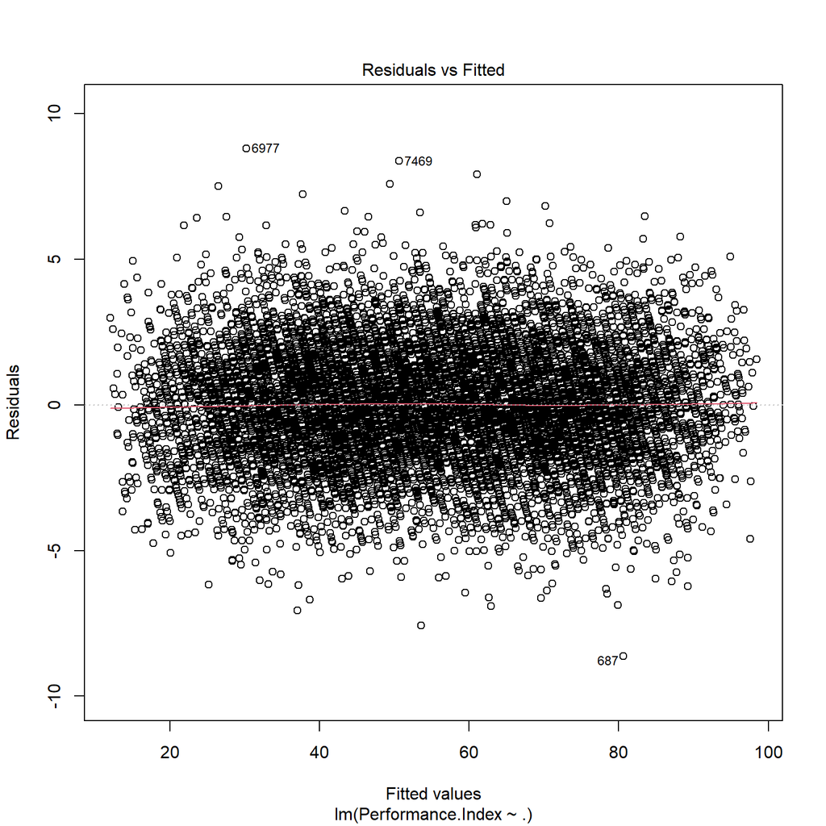

```r
#BP test
plot(mod2,1)
```

```r
library(lmtest)
bptest(mod2)
```

```
    studentized Breusch-Pagan test

data:  mod2
BP = 2.1594, df = 5, p-value = 0.8267
```

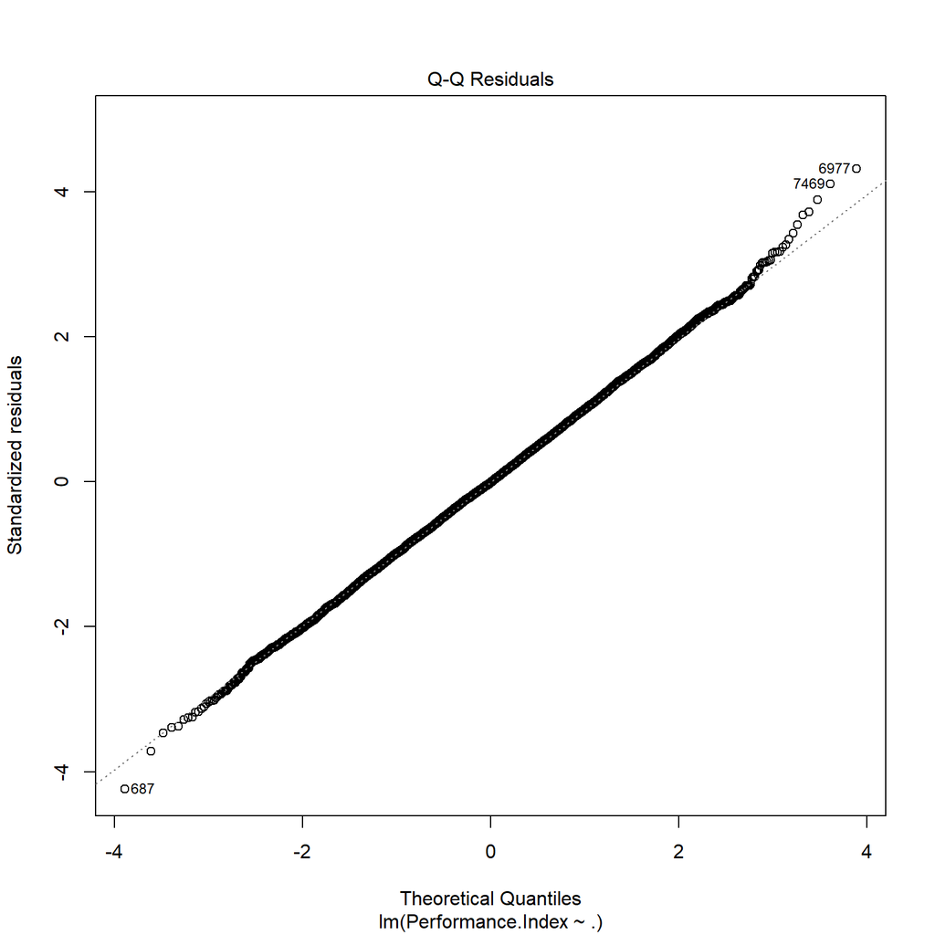

```r
#not violated

#Q-Q plot and normally distributed results
plot(mod2,2)
```

```r
ks.test(rstandard(mod2), "pnorm")
```

```
    Asymptotic one-sample Kolmogorov-Smirnov test

data:  rstandard(mod2)
D = 0.0065975, p-value = 0.7768
alternative hypothesis: two-sided
```

```r
#not violated

#lets try teh lifeexp
```

## Interpretation of multiple linear regression parameters

To account for multiple explanatory variables, when interepreting a $\beta$ associated with a particular explanatory variable $X$, we need to include the phrase **holding all other variables constant**

For the interpretation of the intercept ($\beta_0$), we need to state the fact that this is the predicted value of the response ($\hat{Y}$) when **all of the numeric explanatory variables are equal to 0** and **all of the categorical explanatory variables are equal to their baseline values**

### Example

Interpret the parameter associated with the variable smokeryes in the context of the problem.

$\hat{\beta}_{smokeryes} = 23848.53$ , the expected health expenditures not covered by insurance are $23848.53 dollars more for smokers than for non-smokers, holding all other variables constant

Interpret the parameter associated with the variable bmi in the context of the problem.

$\hat{beta}_{bmi} = 339.19$ , for a 1 $kg/m^2$ increase in BMI, the expected health expenditures not covered by insurance increases by \$339.19, holding all other variables constant.

Interpret the parameter associated with regionnorthwest in the context of the problem.

$\hat{beta}_{regionnw} = -352.96$ , (only comparing northwest and the northeast) indicator would be 1 if they are nw, 0 if they are northeast (simply because NE is the baseline) The expected health expenditures not covered by insurance are \$352.96 less in the northwest region compared to the northeast region

Notes:

- for numeric variables, syntax for interpretation is the same as simple linear regression
- For categorical variables, we are comparing that category to the baseline category

```r
#let's show the linear algebra
X <- model.matrix(charges ~ . , health)
y <- health$charges
beta <- solve(t(X) %*% X) %*% t(X) %*% y
beta
```

```
                       [,1]
(Intercept)     -11938.5386
age                256.8564
sexmale           -131.3144
bmi                339.1935
children           475.5005
smokeryes        23848.5345
regionnorthwest   -352.9639
regionsoutheast  -1035.0220
regionsouthwest   -960.0510
```

## Checking for assumptions of multiple linear regression

The methods of checking the assumptions of homoscedasticity and normally distributed residuals for multiple linear regression are the exact same as the methods for simple linear regression! YAY

### Example

Determine if the assumptions for homoscedasticity and normally distributed residuals for the insurance charges multiple linear regression model are violated.

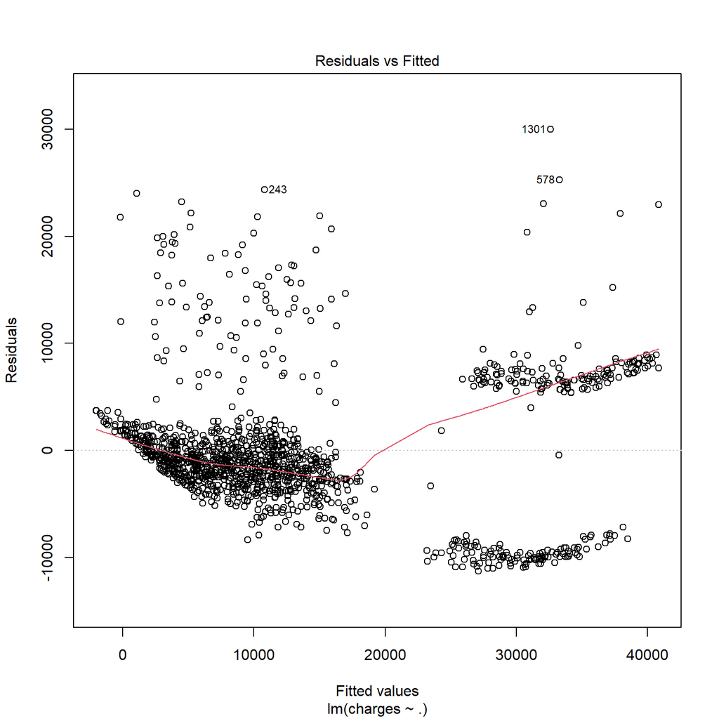

```r
# Homoscedasticity
plot(mod,1)
```

```r
library(lmtest)
bptest(mod)
```

```
    studentized Breusch-Pagan test

data:  mod
BP = 121.74, df = 8, p-value < 2.2e-16
```

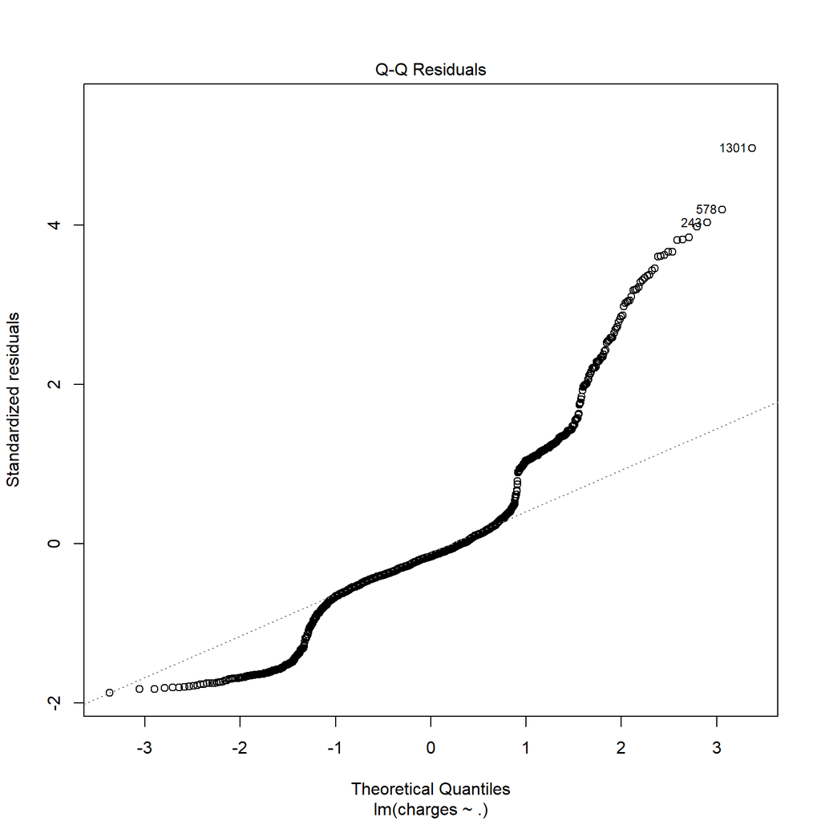

```r
#Violated!!!!

#normality
plot(mod,2)
```

```r
ks.test(rstandard(mod), "pnorm")
```

```
    Asymptotic one-sample Kolmogorov-Smirnov test

data:  rstandard(mod)
D = 0.16079, p-value < 2.2e-16
alternative hypothesis: two-sided
```

```r
#VIOLATED
```

# Confidence Intervals for Model Parameters

Recall the “least squares” regression estimate of $\boldsymbol{\beta}$ is
$$\hat{\boldsymbol{\beta}} = (\boldsymbol{X}'\boldsymbol{X})^{-1}\boldsymbol{X}'\boldsymbol{y}$$

It can be shown that the variance-covariance matrix of our estimate is
$$\text{Var}(\hat{\boldsymbol{\beta}}) = \sigma^2(\boldsymbol{X}'\boldsymbol{X})^{-1}$$

- The diagonal elements produce the variances of our model parameters (i.e. the $1^{st}$ diagonal element is the variance of the intercept $\hat{\beta}_0$, the second element is the variance of the first slope $\hat{\beta}_1$, etc.
- The off-diagonal elements produce the covariance of model parameters (i.e. we can calculate if they are significantly correlated or not)

**Mean Squared Error:** $\text{MSE} = \hat{\sigma}^2 = \frac{\text{SSE}}{dfE} = \frac{1}{n - k} (\boldsymbol{y} - \boldsymbol{X}\hat{\boldsymbol{\beta}})'(\boldsymbol{y} - \boldsymbol{X}\hat{\boldsymbol{\beta}})$

Substituting in $\hat{\sigma}^2$ for $\sigma^2$ and using similar definitions for the distributions of our model parameters that we used in simple linear regression, then for $j = 0,1,\cdots,k-1$, we can say

$$\frac{\hat{\beta}_j - \beta_j}{\hat{\sigma}_{\hat{\beta}_j}} \sim t_{df = n-k}$$

where $\hat{\sigma}_{\hat{\beta}_j}$ is the corresponding value of the standard deviation from $\hat{\text{Var}}(\hat{\boldsymbol{\beta}})$.

A corresponding $100 \times (1 - \alpha)$% confidence interval for $\beta_j$ can be written as

$$\hat{\beta}_j \pm t_{1-\frac{\alpha}{2},n-k}^* \times \hat{\sigma}_{\hat{\beta}_j}$$

### Example

Recall our multiple linear regression for the insurance charges dataset.

- Calculate the variance-covariance matrix for the parameter estimates $\hat{\boldsymbol{\beta}}$.
- Calculate and interpret a 95% confidence interval for the parameter associated with bmi.=

```r
# Vcov by hand
SSE <- t(y-X %*% beta) %*% (y-X %*% beta)
dfE <- 1338 -9 #n = 1338, k = 9
MSE <- (SSE/dfE) [1,1] #extract the scalar
V <- MSE * solve(t(X) %*% X)
V
```

```
                (Intercept)         age      sexmale          bmi    children
(Intercept)      975786.723 -4401.74944 -43670.41734 -22060.68319 -15239.1315
age               -4401.749   141.58261     98.96292    -39.72953    -67.2274
sexmale          -43670.417    98.96292 110852.66544   -446.41472   -788.5259
bmi              -22060.683   -39.72953   -446.41472    817.92971    -50.5491
children         -15239.132   -67.22740   -788.52591    -50.54910  18989.9679
smokeryes        -38741.667   104.51489 -10327.70453    176.03654   -573.9636
regionnorthwest -113047.106    21.72036    659.96742    -17.66675  -1951.3243
regionsoutheast  -20175.472   206.84124    558.77983  -3434.28885    166.9379
regionsouthwest  -80919.421    39.59943    570.93242  -1147.47149  -1741.6263
                  smokeryes regionnorthwest regionsoutheast regionsouthwest
(Intercept)     -38741.6673   -113047.10643     -20175.4721    -80919.42067
age                104.5149        21.72036        206.8412        39.59943
sexmale         -10327.7045       659.96742        558.7798       570.93242
bmi                176.0365       -17.66675      -3434.2889     -1147.47149
children          -573.9636     -1951.32432        166.9379     -1741.62627
smokeryes       170695.6946      4817.07943      -7909.0847      4604.19612
regionnorthwest   4817.0794    226838.62422     113291.4901    113767.51322
regionsoutheast  -7909.0847    113291.49010     229146.2314    118032.73860
regionsouthwest   4604.1961    113767.51322     118032.7386    228419.97574
```

```r
#compare this to R
#vcov(mod) #exactly the same

#95% confidence interval for bmi
est <- beta["bmi",1]
seest <- sqrt(V["bmi", "bmi"])
crit <- qt(1-0.05/2, df=dfE)
est + c(1,1) * crit * seest
```

```
[1] 395.2985 395.2985
```

```r
confint(mod,"bmi", level = 0.95)
```

```
       2.5 %   97.5 %
bmi 283.0884 395.2985
```

```r
confint(mod, "regionsouthwest", level = 0.9)
```

```
                      5 %      95 %
regionsouthwest -1746.729 -173.3728
```

for BMI, (283.09, 395.30): we are 95% confident that a 1 kg/m^2 increase in bmi, the expected health expenditures not covered by health insurance increases by between \$283.09 and \$395.30, holding all other variables constant.

# Hypothesis Testing

## Overall Significance

Recall, the method for testing for a significant linear relationship in simple linear regression.

Reduced Model: $\hat{Y} = \beta_0$

Full Model: $\hat{Y} = \beta_0 + \beta_1X$

The null and alternative hypotheses are:

$$H_0: \beta_1 = 0$$

$$H_a: \beta_1 \neq 0$$

What is this equivalent in multiple dimensions?

**Example:** Consider the below graph for charges not covered by insurance by bmi where the points are colored by sex

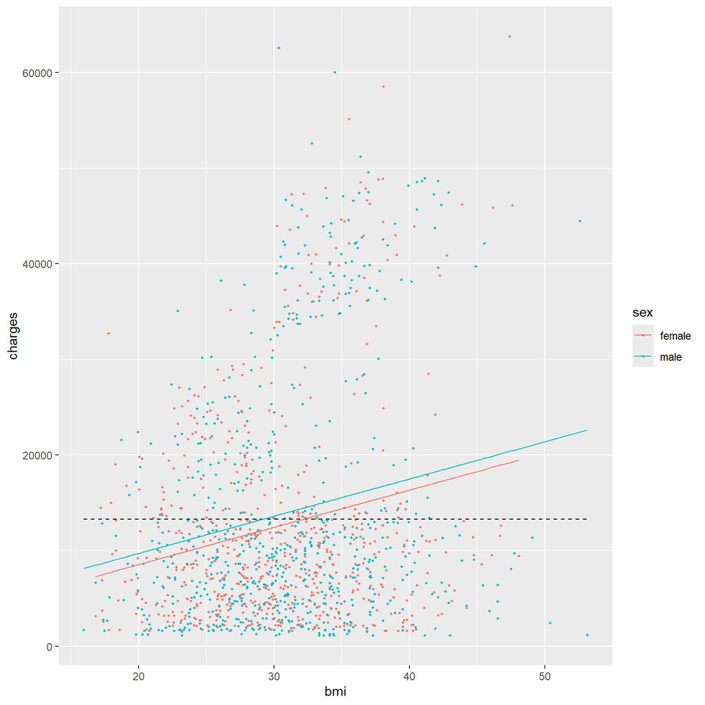

Recall the ANOVA table:

|  | df | Sums of Squares | Mean Square | F Value | Pr(>f) |
| --- | --- | --- | --- | --- | --- |
| Model | $k-1$ | $\text{SSM}$ | $\text{MSM} = \frac{\text{SSM}}{k-1}$ | $F=\frac{\text{MSM}}{\text{MSE}}$ | $P(F_{df1=k-1,df2=n-k} > F)$ |
| Error | $n-k$ | $\text{SSE}$ | $\text{MSE} = \frac{\text{SSE}}{n-k}$ |  |  |
| Total | $n-1$ | $\text{SST}$ |  |  |  |

This provides us test statistics and p-values for the test for overall significance of our linear regression model.

- F-statistic: $\frac{\text{Explained Variance}}{\text{Unexplained Variance}} = \frac{\text{SSM}/(k-1)}{\text{SSE}/(n-k)}$
  - $k-1$ are the model degrees of freedom
  - $n-k$ are the error degrees of freedom
- $p-value$: Calculated using an F-distribution with $k-1$ and $n-k$ degrees of freedom
- If $F$ is significantly large, then we have enough information to say the variance explained by the model is significantly larger than the variance left unexplained.
- If $p-value < \alpha$, reject $H_0$ and we conclude the linear model with our explanatory variables is statistically significantly better at predicting our response.
- If $p-value \geq \alpha$, fail to reject $H_0$ and we conclude the linear model with our explanatory variables is not statistically significantly better at predicting our response.

### Example

Perform a test for a significant linear regression for net charges not covered by insurance with all other explanatory variables included in the model.

## Partial Significance

Now, suppose we know that bmi is a statistically significant explanatory variable in our linear model. Does adding any additional explanatory variables to our linear model improve the model fit?

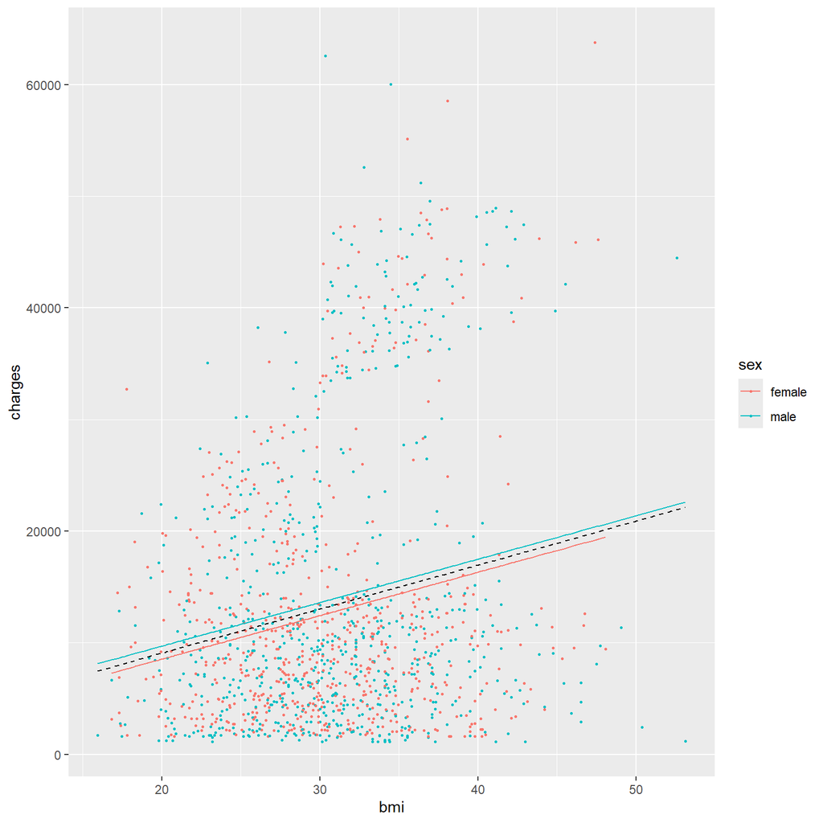

In general, for a total of $k-1$ explanatory variables and we assume the first $l-1$ variables are already included in the model ($l < k$) (i.e. the first $l-1$ are determined to be statistically significant:

- Reduced Model: $\hat{Y} = \beta_0 + \beta_1 X_1 + \cdots + \beta_{l-1} X_{l-1}$
- Full Model: $\hat{Y} = \beta_0 + \beta_1 X_1 + \cdots + \beta_{l-1} X_{l-1} + \beta_lX_l + \cdots + \beta_{k-1} X_{k-1}$

Recall, that for the reduced model:

$$\text{SST} = \text{SSM}_{red} + \text{SSE}_{red}$$

By adding additional explanatory variables to our model, we can take some sums of squares from $\text{SSE}_{red}$ and add them to our full model! In other words:

$$\text{SSE}_{red} = \text{SSM}_{add} + \text{SSE}_{full}$$

where

- $\text{SSM}_{add}$ are the sums of squares added to the model sums squares when going from the reduced model to the full model (i.e. $\text{SSM}_{full} = \text{SSM}_{red} + \text{SSM}_{add}$)
- $\text{SSE}_{full}$ are the sums of squares for the full model

The ANOVA Table looks as follows

|  | df | Sums of Squares | Mean Square | F Value | Pr(>f) |
| --- | --- | --- | --- | --- | --- |
| Reduced Model | $l-1$ | $\text{SSM}_{red}$ | $\text{MSM}_{red} = \frac{\text{SSM}_{red}}{l-1}$ | $F=\frac{\text{MSM}_{red}}{\text{MSE}_{full}}$ | $P(F_{df1=l-1,df2=n-k} > F)$ |
| Additional | $k - l$ | $\text{SSM}_{add}$ | $\text{MSM}_{add} = \frac{\text{SSM}_{add}}{k-l}$ | $F=\frac{\text{MSM}_{add}}{\text{MSE}_{full}}$ | $P(F_{df1=k-l,df2=n-k} > F)$ |
| Error | $n-k$ | $\text{SSE}_{full}$ | $\text{MSE}_{full} = \frac{\text{SSE}_{full}}{n-k}$ |  |  |
| Total | $n-1$ | $\text{SST}$ |  |  |  |

Let’s see what the ANOVA table looks like for our full linear model

```r
anova(mod)
```

[output not shown]

### Example

Perform a hypothesis test to determine if adding sex to a linear regression model that already includes bmi is statistically significant in predicting charges not covered by insurance.

### Example

Perform a hypothesis test to determine if adding any other explanatory variable to a linear regression model that already includes bmi is statistically significant in predicting charges not covered by insurance.

**One more thing!**

- If $\text{SSM}_{red} \leq \text{SSM}_{full}$, $r^2_{red} \leq r^2_{full}$
- $r^2_{full} - r^2_{red}$ is the percent variation in $Y$ that is explained by adding variables $X_l,\cdots,X_{k-1}$ to a linear model that already includes $X_1,\cdots,X_{l-1}$

# Confidence Intervals for MLR Predictions

Suppose we have some values of the explanatory variables $\boldsymbol{x}_0$. The mean of the response variable for our linear model is defined as

$$\mu_{Y|\boldsymbol{x}_0} = \boldsymbol{x}_0 \boldsymbol{\beta},$$

an estimate of this mean is

$$\hat{\mu}_{Y|\boldsymbol{x}_0} = \boldsymbol{x}_0 \hat{\boldsymbol{\beta}},$$

and the variance of this estimate is

$$\text{Var}(\hat{\mu}_{Y|\boldsymbol{x}_0}) = \sigma^2 \boldsymbol{x}_0(\boldsymbol{X}'\boldsymbol{X})^{-1}\boldsymbol{x}_0'.$$

Therefore, like in simple linear regression where $\hat{\sigma}^2$ is substituted for $\sigma^2$, we can say that

$$\frac{\hat{\mu}_{Y|\boldsymbol{x}_0} - \mu_{Y|\boldsymbol{x}_0}}{\sqrt{\hat{\text{Var}}(\hat{\mu}_{Y|\boldsymbol{x}_0})}} \sim t_{df=n-k},$$

and we can calculate a $C = 100\times(1-\alpha)$% confidence interval for $\mu_{Y|\boldsymbol{x}_0}$ as
$$\hat{\mu}_{Y|\boldsymbol{x}_0} \pm t_{1-\frac{\alpha}{2},n-k}\times \sqrt{\hat{\text{Var}}(\hat{\mu}_{Y|\boldsymbol{x}_0})}.$$

### Example

Assuming our full model, calculate a 95% confidence interval for the average amount of health expenditures for a 32 year old male non-smoker from the northeast region with 0 children and a bmi of 25 $kg/m^2$.

# Prediction Intervals for MLR Predictions

Similarly, we can estimate a prediction for a particular individual for a given $\boldsymbol{x}_0$ as

$$\hat{Y}_{\boldsymbol{x}_0} = \boldsymbol{x}_0 \hat{\boldsymbol{\beta}},$$

and the variance of this estimate is

$$\text{Var}(\hat{Y}_{\boldsymbol{x}_0}) = \sigma^2(1 + \boldsymbol{x}_0(\boldsymbol{X}'\boldsymbol{X})^{-1}\boldsymbol{x}_0').$$

Therefore, like in simple linear regression where $\hat{\sigma}^2$ is substituted for $\sigma^2$, we can say that

$$\frac{\hat{Y}_{\boldsymbol{x}_0} - Y_{\boldsymbol{x}_0}}{\sqrt{\hat{\text{Var}}(\hat{Y}_{\boldsymbol{x}_0})}} \sim t_{df=n-k},$$

and we can calculate a $C = 100\times(1-\alpha)$% confidence interval for $Y_{\boldsymbol{x}_0}$ as
$$\hat{Y}_{\boldsymbol{x}_0} \pm t_{1-\frac{\alpha}{2},n-k}\times \sqrt{\hat{\text{Var}}(\hat{Y}_{\boldsymbol{x}_0})}.$$

### Example

Assuming our full model, calculate a 95% prediction interval for the average amount of health expenditures for a 32 year old male non-smoker from the northeast region with 0 children and a bmi of 25 $kg/m^2$.